# Analyzing Rotterdam Study Data - Tips and Tricks

Anna Streiber & Sanne Hoepel

Last edited on 28-11-2023

Hello!

We’re happy to see your interest in diving into the world of analyzing Rotterdam Study data using R Markdown.

This comprehensive document is your gateway to unlocking the full potential of Rotterdam Study data analysis. Here, we’ll guide you through the process of accessing the data and setting up R Markdown. We’ve also created a list of valuable free resources to elevate your Markdown skills.

Entering the realm of data analysis, especially with large datasets like those in the Rotterdam Study, can feel daunting. But remember, you’re not alone on this journey. Many have tread this path before you, and their knowledge is at your disposal. Our aim is to smooth your entry into the project by providing step-by-step guidance through data acquisition, cleaning, and analysis. We’ll walk you through the process of obtaining your Rotterdam Study data, setting up Markdown for seamless documentation, and introduce you to free resources for data cleaning and script sharing.

Even if you’ve worked with Rotterdam Study data in the past, this document holds the potential to enhance your efficiency and reveal new insights. Your contribution to this project may not only benefit you but also pave the way for future PhD students. Together, we can build a valuable resource that continues to evolve and aid data enthusiasts like yourself.

## Getting your data

If you want to work with Rotterdam Study data, your should first check if you can find them on the [Data Wiki](https://epi-wiki.erasmusmc.nl/wiki/).

Below, you see a step-by-step guide on how to search for and download data.

[figure not shown]

[figure not shown]

After selecting your study cohort, you see relevant information regarding the data such as the data dictionary and a list of variables. If you scroll down, you will be able to see the dataset and add it to your “shopping basket”:

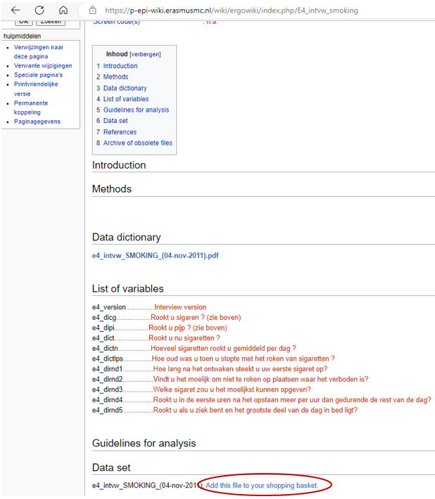

Once, you have added the file to your basket, you will be presented with a file overview. If you confirm your choice, you are required to fill in your ID and your password. After confirming your choice and entering your credentials, the dataset will be sent to your Erasmus MC e-mail.

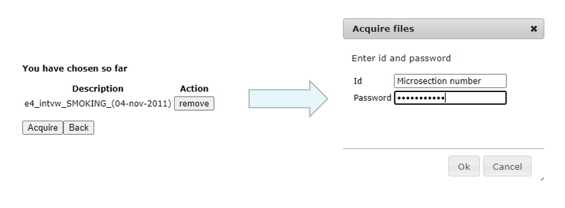

Please talk to your supervisors if you do not have an Ergo Wiki account yet. They will help you setting it up.

If the data you need are not on the Wiki, there is often a responsible person listed that you can contact for data-specific questions. Otherwise, you can send an e-mail to Frank van Rooij, the data manager of the epidemiology department. Always be specific in what you need and provide a short explanation of the corresponding project.

## Reasons for Using R Markdown

R and R Markdown are two closely related tools that can be used within R Studio. R is a programming language for statistical computing and data analysis, while R Markdown is a dynamic document format that blends code, narrative text, and visualizations into a single, easily shareable document. The key difference lies in their usage: R is primarily for coding and data analysis, whereas R Markdown is a tool for creating reproducible and transparent reports and documents. However, you can combine both by easily inserting R code into a Markdown document, thereby combining powerful features of both tools.

R Markdown can be superior to typical scripts for several reasons:

1. It offers **transparency** by seamlessly integrating code with explanatory text and visual outputs. This transparency allows readers to understand the thought process behind the analysis, making it easier for collaborators to provide feedback or reproduce the work
2. R Markdown enhances **reproducibility** as it encapsulates the entire workflow within a single document. This means that anyone can replicate the analysis by executing the R Markdown document, eliminating the need to manually recreate steps
3. R Markdown promotes best practices in **documentation**, making it easier to track changes, share findings, and collaborate effectively. Especially, when it is combined with Git (if you want to know more about that, check the free resources below)

### Setting up R Markdown

Before getting started in R Markdown, make sure that you have downloaded R and R studio. Both can be downloaded [here](https://posit.co/download/rstudio-desktop/).

Prior to working in R Markdown or R in general, it is recommended to create an R project. In a nutshell, an R project is a working directory that allows you to store your work in a self-contained folder. How to set up your own R project is explained [here](https://support.posit.co/hc/en-us/articles/200526207-Using-RStudio-Projects).

If you are working in R studio, you can immediately use R markdown by opening an R Markdown document:

[figure not shown]

After clicking on the R Markdown tab, you can specify the title of your documents as well as the author and the date. The default output format is usually set to HTML. It can be changed to PDF or word. However, formatting your document into a PDF requires the installation of **LaTex**! Before you pick this option make sure to check if LaTex is installed because otherwise, you might run into errors.

As you can see on the right, you can always change the output format while working in your Markdown script.

[figure not shown]

As you can see, the empty script already contains some information regarding the use and syntax of Markdown. If you want to dive more deeply into analyzing your data using Markdown, you can refer to the free resources below.

## Free resources

Here, we’ve compiled a valuable collection of free resources to support you in three crucial aspects:

data cleaning, conducting analyses, and effectively working with R Markdown.

**Important Note**

As you delve into these resources, we encourage you to approach them critically. If you happen to come across any errors or have suggestions for improvement, please send them to Sanne Hoepel or Anna Streiber. It’s essential to recognize that identifying mistakes is an inherent part of refining data analysis and fostering transparency throughout our department. Any errors discovered will not be attributed to specific individuals; instead, they will serve as opportunities for collective learning and improvement.

Your feedback on any mistakes or ideas for improvement is highly valued. Together, we can elevate the quality of our analyses and documentation, benefiting our entire community.

### Data Cleaning

Once you have downloaded your data from the Wiki or got them from Frank/ your supervisor, you need to prepare them for data analysis. The [Data cleaning guide](https://rs-data-guide.netlify.app/) is a very helpful tool that has been developed by former PhD students of the department of epidemiology. It contains information on the structure of the Rotterdam Study data and code/scripts that helps you in both importing and transforming data.

### Data Repository

We created a data repository containing multiple R scripts from projects completed within our department. It is conveniently located on the epidemiology v-drive (V:\0_Script_Repository_Epi) where you can access it easily. We aim to continually expand this repository over time. Please, get in touch with us if you would also like to contribute something to this repository.

### R Markdown

Below, you find free resources to deepen your understanding regarding R Markdown. The cheat sheet provides a comprehensive overview of the core Markdown syntax. The YouTube channel of the RLadies Sydney includes more hands-on tutorials on both using R and Markdown. The R Markdown Definite Guide and the R Markdown Cookbook are most detailed and contain all information regarding syntax, packages, data presentation, and examples.Finally, the github guide teaches you how to make your code more reproducible and how to connect R studio to GitHub.

- [R Markdown Cheat Sheet](https://www.rstudio.com/wp-content/uploads/2015/02/rmarkdown-cheatsheet.pdf)
- [R Ladies Sydney](https://rladiessydney.org/courses/ryouwithme/04-markymark-0/)
- [R Markdown: The Definitive Guide](https://bookdown.org/yihui/rmarkdown/)
- [R Markdown cookbook](https://bookdown.org/yihui/rmarkdown-cookbook/)
- [Using Git and R Markdown (more advanced)](https://andrewmaclachlan.github.io/CASA0005repo/git-github-and-rmarkdown.html#git-and-github)
- [Training materials](https://www.esciencecenter.nl/training-materials/) provided by the Dutch eScience center

Of course, there are much more online resources but for now, this should give you a complete overview.

> Now, you should be provided with the basics to give it a try! May the coding begin!